# Bellabeat Data Analysis Case Study

Makori Nyachaki

2024-12-30

## Introduction

Bellabeat is a *Smart Device* manufacturer for women’s smart devices. These are health wellness wearable used to track physical activity, sleep, stress, menstrual cycle and mindful habits. Bellabeat is a successful start up with the ability to growing to becoming a global company. The Chief Creative Officer and co-founder of Bellabeat Urška Sršen, believes that analyzing the available data on smart devices will help identify usage trends and patterns that will help the company identify expansion and growth opportunities and design a better marketing strategy.

## Analysis Questions

1. What are the trends and patterns in usage of smart devices?
2. How do these trends and patterns correlate with Bellabeat’s smart devices?
3. How will these trends impact Bellabeats’ marketing strategy?

## Business Task

Identify potential growth opportunities and recommendations for the marketing strategy for the Bellabeat company.

## Installing and Loading Packages

During the analysis process, I used the following standardized R package libraries for the data cleaning and processing and visualization:

1. tidyverse
2. lubridate
3. dplyr
4. magritrr To install and load them:

```r
# Install
install.packages("tidyverse")
install.packages("lubridate")
install.packages("dplyr")
install.packages("magrittr")
# Load
library(tidyverse)
```

```r
library(lubridate)
library(dplyr)
library(ggplot2)
library(magrittr)
library(janitor)
```

## Loading Datasets

I imported the following datasets from the data given since they were most in alignment with the goals of Bellabeats’ technology: i. activities - Imported from dailyActivity_merged.csv file ii. calories - imported from the hourlyCalories_merged.csv” file. iii. intensities - imported from the hourlyIntensities_merged.csv file iv. weight - imported from weightLogInfo_merged.csv file v. sleep - imported from sleepDay_merged.csv file

*Note:* All the files are in the bellabeat 1 folder which are the most current

```r
# Creating data tables and getting their secifications
# ~/Desktop/projects_data_analysis/Bellabeat-Case-Study---Capstone-Project/bellabeat_1
# /cloud/project/bellabeat_1
activities <- read_csv("~/Desktop/projects_data_analysis/Bellabeat-Case-Study---Capstone-Project/bellabeat_1/dailyActivity_merged.csv")
# Calories
calories <- read_csv("~/Desktop/projects_data_analysis/Bellabeat-Case-Study---Capstone-Project/bellabeat_1/hourlyCalories_merged.csv")
# intensities
intensities <- read_csv("~/Desktop/projects_data_analysis/Bellabeat-Case-Study---Capstone-Project/bellabeat_1/hourlyIntensities_merged.csv")
# sleep
sleep <- read_csv("~/Desktop/projects_data_analysis/Bellabeat-Case-Study---Capstone-Project/bellabeat_1/sleepDay_merged.csv")
# weigth
weight <- read_csv("~/Desktop/projects_data_analysis/Bellabeat-Case-Study---Capstone-Project/bellabeat_1/weightLogInfo_merged.csv")
```

I used the spec(), and head functions to check on the dataset specifications and viewing its structure.

```r
# Specs, then do for each table
spec(activities)
# Sample, then do for each table
head(activities)
```

```
## # A tibble: 6 × 15
##           Id ActivityDate TotalSteps TotalDistance TrackerDistance
##        <dbl> <chr>             <dbl>         <dbl>           <dbl>
## 1 1503960366 4/12/2016         13162          8.5             8.5
## 2 1503960366 4/13/2016         10735          6.97            6.97
## 3 1503960366 4/14/2016         10460          6.74            6.74
## 4 1503960366 4/15/2016          9762          6.28            6.28
## 5 1503960366 4/16/2016         12669          8.16            8.16
## 6 1503960366 4/17/2016          9705          6.48            6.48
## # ℹ 10 more variables: LoggedActivitiesDistance <dbl>,
## #   VeryActiveDistance <dbl>, ModeratelyActiveDistance <dbl>,
## #   LightActiveDistance <dbl>, SedentaryActiveDistance <dbl>,
## #   VeryActiveMinutes <dbl>, FairlyActiveMinutes <dbl>,
## #   LightlyActiveMinutes <dbl>, SedentaryMinutes <dbl>, Calories <dbl>
```

## Data Cleaning

#### Date Time

I realised there was an error in the date-time columns since date was stored in character format. I changed the dates into date time fields. I also had to split the datetime to separate fields in like date and time to display the day and time respectively.

```r
sleep$SleepDay <- parse_date_time(sleep$SleepDay, orders = "%m/%d/%Y %H:%M:%S %p")
sleep$date <- format(sleep$SleepDay, format("%m/%d/%Y"))
calories$ActivityHour <- parse_date_time(calories$ActivityHour, orders = "%m/%d/%Y %H:%M:%S %p")
activities$ActivityDate <- parse_date_time(activities$ActivityDate, orders = "%m/%d/%Y")
activities$date <- format(activities$ActivityDate, format("%m/%d/%Y"))
# Splitted the ActivityHour column to form the date and time columns in the intensities dataset
intensities$ActivityHour <- parse_date_time(intensities$ActivityHour, orders = "%m/%d/%Y %H:%M:%S %p")
intensities$date <- format(intensities$ActivityHour, format("%m/%d/%Y"))
intensities$time <- format(intensities$ActivityHour, format("%H:%M:%S"))
weight$Date <- parse_date_time(weight$Date, orders = "%m/%d/%Y %H:%M:%S %p")
```

#### Cleaning Names

I changed all the column names from mixed case to snake case for my preferences and ease of readability.

```r
sleep <- sleep %>%
  clean_names()
calories <- calories %>%
  clean_names()
intensities <- intensities %>%
  clean_names()
activities <- activities %>%
  clean_names()
weight <- weight %>%
  clean_names()
```

#### Sorting and Organizing

I sorted and organized the datasets in ascending order.

```r
sleep <- sleep %>%
  arrange(sleep_day)
activities <- activities %>%
  arrange(activity_date)
intensities <- intensities %>%
  arrange(activity_hour)
weight <- weight %>%
  arrange(date)
calories <- calories %>%
  arrange(activity_hour)
```

#### Duplicates

I checked for the duplicates and I found duplicates in the *sleep* dataset

```r
sleep %>%
  get_dupes()
```

```
## No variable names specified - using all columns.
```

```
## # A tibble: 6 × 7
##           id sleep_day           total_sleep_records total_minutes_asleep
##        <dbl> <dttm>                            <dbl>                <dbl>
## 1 4388161847 2016-05-05 00:00:00                   1                  471
## 2 4388161847 2016-05-05 00:00:00                   1                  471
## 3 4702921684 2016-05-07 00:00:00                   1                  520
## 4 4702921684 2016-05-07 00:00:00                   1                  520
## 5 8378563200 2016-04-25 00:00:00                   1                  388
## 6 8378563200 2016-04-25 00:00:00                   1                  388
## # ℹ 3 more variables: total_time_in_bed <dbl>, date <chr>, dupe_count <int>
```

This will be helpful more especially while aggregating data.

#### Exploring and Confirming Datasets

1. Confirmed the number of clients who submitted data for each category:

```r
n_distinct(sleep$id)
```

```
## [1] 24
```

```r
n_distinct(activities$id)
```

```
## [1] 33
```

```r
n_distinct(calories$id)
```

```
## [1] 33
```

```r
n_distinct(weight$id)
```

```
## [1] 8
```

```r
n_distinct(intensities$id)
```

```
## [1] 33
```

*Observations* From the data we were told that 30 customers willingly submitted the data. However, this was not the case for other datasets had only 8 customers for the weight submitting the data. This is a very low figure to use and draw conclusions from. The rest of the data met atlest the minimum number of customers submitting the data for analysis example 24 and 33 from a majority of datasets.

2. View the structure of the newly cleaned datasets. I used the *head()* function.

```r
head(sleep)
```

```
## # A tibble: 6 × 6
##           id sleep_day           total_sleep_records total_minutes_asleep
##        <dbl> <dttm>                            <dbl>                <dbl>
## 1 1503960366 2016-04-12 00:00:00                   1                  327
## 2 1927972279 2016-04-12 00:00:00                   3                  750
## 3 2026352035 2016-04-12 00:00:00                   1                  503
## 4 3977333714 2016-04-12 00:00:00                   1                  274
## 5 4020332650 2016-04-12 00:00:00                   1                  501
## 6 4445114986 2016-04-12 00:00:00                   2                  429
## # ℹ 2 more variables: total_time_in_bed <dbl>, date <chr>
```

```r
head(activities)
```

```
## # A tibble: 6 × 16
##           id activity_date       total_steps total_distance tracker_distance
##        <dbl> <dttm>                    <dbl>          <dbl>            <dbl>
## 1 1503960366 2016-04-12 00:00:00       13162          8.5              8.5
## 2 1624580081 2016-04-12 00:00:00        8163          5.31             5.31
## 3 1644430081 2016-04-12 00:00:00       10694          7.77             7.77
## 4 1844505072 2016-04-12 00:00:00        6697          4.43             4.43
## 5 1927972279 2016-04-12 00:00:00         678          0.470            0.470
## 6 2022484408 2016-04-12 00:00:00       11875          8.34             8.34
## # ℹ 11 more variables: logged_activities_distance <dbl>,
## #   very_active_distance <dbl>, moderately_active_distance <dbl>,
## #   light_active_distance <dbl>, sedentary_active_distance <dbl>,
## #   very_active_minutes <dbl>, fairly_active_minutes <dbl>,
## #   lightly_active_minutes <dbl>, sedentary_minutes <dbl>, calories <dbl>,
## #   date <chr>
```

```r
head(weight)
```

```
## # A tibble: 6 × 8
##           id date                weight_kg weight_pounds   fat   bmi
##        <dbl> <dttm>                  <dbl>         <dbl> <dbl> <dbl>
## 1 8877689391 2016-04-12 06:47:11      85.8          189.    NA  25.7
## 2 6962181067 2016-04-12 23:59:59      62.5          138.    NA  24.4
## 3 1927972279 2016-04-13 01:08:52     134.           294.    NA  47.5
## 4 8877689391 2016-04-13 06:55:00      84.9          187.    NA  25.4
## 5 6962181067 2016-04-13 23:59:59      62.1          137.    NA  24.2
## 6 8877689391 2016-04-14 06:48:43      84.5          186.    NA  25.3
## # ℹ 2 more variables: is_manual_report <lgl>, log_id <dbl>
```

```r
head(calories)
```

```
## # A tibble: 6 × 3
##           id activity_hour       calories
##        <dbl> <dttm>                 <dbl>
## 1 1503960366 2016-04-12 00:00:00       81
## 2 1624580081 2016-04-12 00:00:00       55
## 3 1644430081 2016-04-12 00:00:00       89
## 4 1844505072 2016-04-12 00:00:00       56
## 5 1927972279 2016-04-12 00:00:00       85
## 6 2022484408 2016-04-12 00:00:00       62
```

```r
head(intensities)
```

```
## # A tibble: 6 × 6
##           id activity_hour       total_intensity average_intensity date    time
##        <dbl> <dttm>                        <dbl>             <dbl> <chr>   <chr>
## 1 1503960366 2016-04-12 00:00:00              20            0.333  04/12/… 00:0…
## 2 1624580081 2016-04-12 00:00:00               4            0.0667 04/12/… 00:0…
## 3 1644430081 2016-04-12 00:00:00               2            0.0333 04/12/… 00:0…
## 4 1844505072 2016-04-12 00:00:00               0            0      04/12/… 00:0…
## 5 1927972279 2016-04-12 00:00:00               0            0      04/12/… 00:0…
## 6 2022484408 2016-04-12 00:00:00               0            0      04/12/… 00:0…
```

## Processing and Analysis

#### Summary Statitics

This is the summary statistics from some of the datasets which will be giving us some insights while doing analysis.

```r
activities %>%
  select(very_active_minutes, fairly_active_minutes, lightly_active_minutes, sedentary_minutes) %>%
  summary()
```

```
##  very_active_minutes fairly_active_minutes lightly_active_minutes
##  Min.   :  0.00      Min.   :  0.00        Min.   :  0.0
##  1st Qu.:  0.00      1st Qu.:  0.00        1st Qu.:127.0
##  Median :  4.00      Median :  6.00        Median :199.0
##  Mean   : 21.16      Mean   : 13.56        Mean   :192.8
##  3rd Qu.: 32.00      3rd Qu.: 19.00        3rd Qu.:264.0
##  Max.   :210.00      Max.   :143.00        Max.   :518.0
##  sedentary_minutes
##  Min.   :   0.0
##  1st Qu.: 729.8
##  Median :1057.5
##  Mean   : 991.2
##  3rd Qu.:1229.5
##  Max.   :1440.0
```

```r
activities %>%
  select(total_distance, very_active_distance, moderately_active_distance, light_active_distance, sedentary_active_distance) %>%
  summary()
```

```
##  total_distance   very_active_distance moderately_active_distance
##  Min.   : 0.000   Min.   : 0.000       Min.   :0.0000
##  1st Qu.: 2.620   1st Qu.: 0.000       1st Qu.:0.0000
##  Median : 5.245   Median : 0.210       Median :0.2400
##  Mean   : 5.490   Mean   : 1.503       Mean   :0.5675
##  3rd Qu.: 7.713   3rd Qu.: 2.053       3rd Qu.:0.8000
##  Max.   :28.030   Max.   :21.920       Max.   :6.4800
##  light_active_distance sedentary_active_distance
##  Min.   : 0.000        Min.   :0.000000
##  1st Qu.: 1.945        1st Qu.:0.000000
##  Median : 3.365        Median :0.000000
##  Mean   : 3.341        Mean   :0.001606
##  3rd Qu.: 4.782        3rd Qu.:0.000000
##  Max.   :10.710        Max.   :0.110000
```

```r
activities %>%
  select(total_steps, total_distance, tracker_distance, calories) %>%
  summary()
```

```
##   total_steps    total_distance   tracker_distance    calories
##  Min.   :    0   Min.   : 0.000   Min.   : 0.000   Min.   :   0
##  1st Qu.: 3790   1st Qu.: 2.620   1st Qu.: 2.620   1st Qu.:1828
##  Median : 7406   Median : 5.245   Median : 5.245   Median :2134
##  Mean   : 7638   Mean   : 5.490   Mean   : 5.475   Mean   :2304
##  3rd Qu.:10727   3rd Qu.: 7.713   3rd Qu.: 7.710   3rd Qu.:2793
##  Max.   :36019   Max.   :28.030   Max.   :28.030   Max.   :4900
```

```r
weight %>%
  select(weight_kg, weight_pounds, bmi) %>%
  summary()
```

```
##    weight_kg      weight_pounds        bmi
##  Min.   : 52.60   Min.   :116.0   Min.   :21.45
##  1st Qu.: 61.40   1st Qu.:135.4   1st Qu.:23.96
##  Median : 62.50   Median :137.8   Median :24.39
##  Mean   : 72.04   Mean   :158.8   Mean   :25.19
##  3rd Qu.: 85.05   3rd Qu.:187.5   3rd Qu.:25.56
##  Max.   :133.50   Max.   :294.3   Max.   :47.54
```

```r
intensities %>%
  select(total_intensity, average_intensity) %>%
  summary()
```

```
##  total_intensity  average_intensity
##  Min.   :  0.00   Min.   :0.0000
##  1st Qu.:  0.00   1st Qu.:0.0000
##  Median :  3.00   Median :0.0500
##  Mean   : 12.04   Mean   :0.2006
##  3rd Qu.: 16.00   3rd Qu.:0.2667
##  Max.   :180.00   Max.   :3.0000
```

```r
sleep %>%
  select(total_sleep_records, total_minutes_asleep, total_time_in_bed) %>%
  summary()
```

```
##  total_sleep_records total_minutes_asleep total_time_in_bed
##  Min.   :1.000       Min.   : 58.0        Min.   : 61.0
##  1st Qu.:1.000       1st Qu.:361.0        1st Qu.:403.0
##  Median :1.000       Median :433.0        Median :463.0
##  Mean   :1.119       Mean   :419.5        Mean   :458.6
##  3rd Qu.:1.000       3rd Qu.:490.0        3rd Qu.:526.0
##  Max.   :3.000       Max.   :796.0        Max.   :961.0
```

*Observations from the summaries* These were some of the observations from the summaries:

1. The following were the observations from the activities dataset:
   1. The average sedentary active time was 991.2 minutes which is a very large one stays without any activity. It needs to be reduced and be supplemented with other activities including physical activity. The mean of very active time is 21.16 minutes which is a third of a hour.
   2. The average very active distance is 1.503 and it is less compared to the light active distance whose average is 3.341. The sedentary active distance average stand at 0.001606 which is very low and it implies atleast people exercise by walking as the physical activity.
   3. The tracker and total distance mean vary awhich implies either the customers do not walk to complete all the distance or some faults somewhere.
   4. The average total steps is 7638 steps made per each person for a whole day.
2. The average of the total intensity hourly is 12.04 and the avaerage of the average intensity is 0.2006. This needs to be increased inorder to realise the effectiveness of each activity.
3. The average time in bed is 458.6 minutes and the average time asleed is 419.5 minutes and atleast each person must sleep at least once in a day for 7 hours.

#### Merging Data

Merged the *activities* and *sleep* datasets on the common field *id* and *date*. The *date* field is the one I formed during the data cleaning process. We form a new dataset *activity_sleep* which we use for visualizing our data. This is achievd by an inner join where all values which merge the criteria set are merged together

```r
activity_sleep <- merge(sleep, activities, by = c('id', 'date'))
```

View the new dataset structure

```r
head(activity_sleep)
```

```
##           id       date  sleep_day total_sleep_records total_minutes_asleep
## 1 1503960366 04/12/2016 2016-04-12                   1                  327
## 2 1503960366 04/13/2016 2016-04-13                   2                  384
## 3 1503960366 04/15/2016 2016-04-15                   1                  412
## 4 1503960366 04/16/2016 2016-04-16                   2                  340
## 5 1503960366 04/17/2016 2016-04-17                   1                  700
## 6 1503960366 04/19/2016 2016-04-19                   1                  304
##   total_time_in_bed activity_date total_steps total_distance tracker_distance
## 1               346    2016-04-12       13162           8.50             8.50
## 2               407    2016-04-13       10735           6.97             6.97
## 3               442    2016-04-15        9762           6.28             6.28
## 4               367    2016-04-16       12669           8.16             8.16
## 5               712    2016-04-17        9705           6.48             6.48
## 6               320    2016-04-19       15506           9.88             9.88
##   logged_activities_distance very_active_distance moderately_active_distance
```

[output cut: 20 more lines]

## Visualization

*Comparisons between the time asleep and sedentary active minutes*

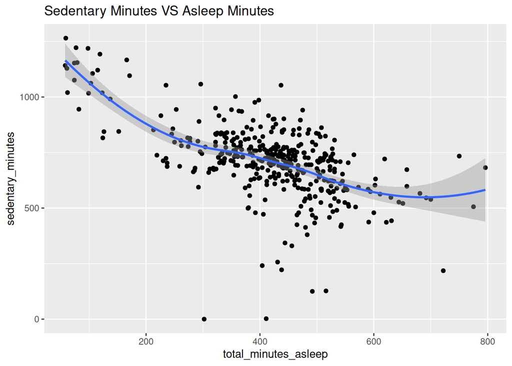

```r
activity_sleep %>%
  ggplot(mapping = aes(x=total_minutes_asleep, y=sedentary_minutes)) + geom_point(stat = "identity") +
  geom_smooth() + labs(title = "Sedentary Minutes VS Asleep Minutes")
```

*Observation*

*Comparisons between the total steps and calories*

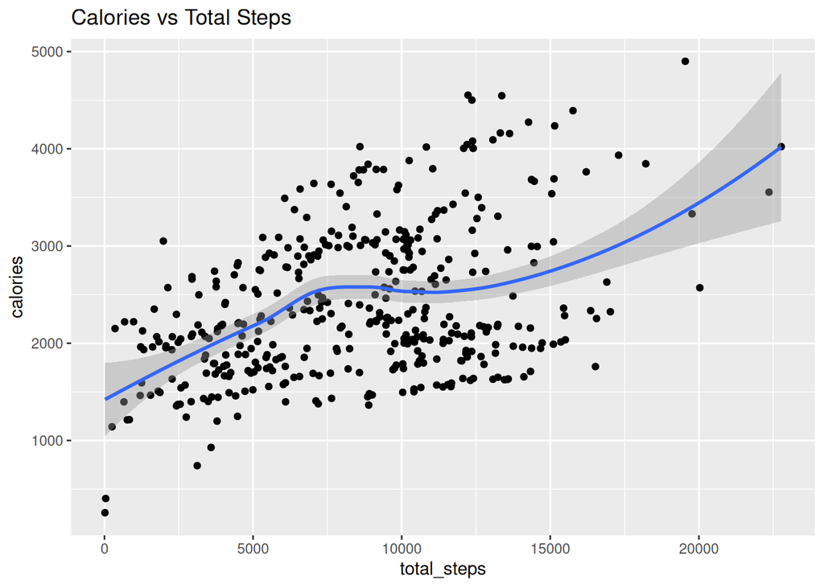

```r
activity_sleep %>%
  ggplot(mapping = aes(x = total_steps, y = calories)) + geom_point(stat = "identity") + geom_smooth() +
  labs(title = "Calories vs Total Steps")
```

*Observation:* As the number of steps increase the number of calories burnt increases. This is true since the more we walk the more number of calories are oxidized to release energy.

*Comparison between total minutes in bed and total minutes asleep*

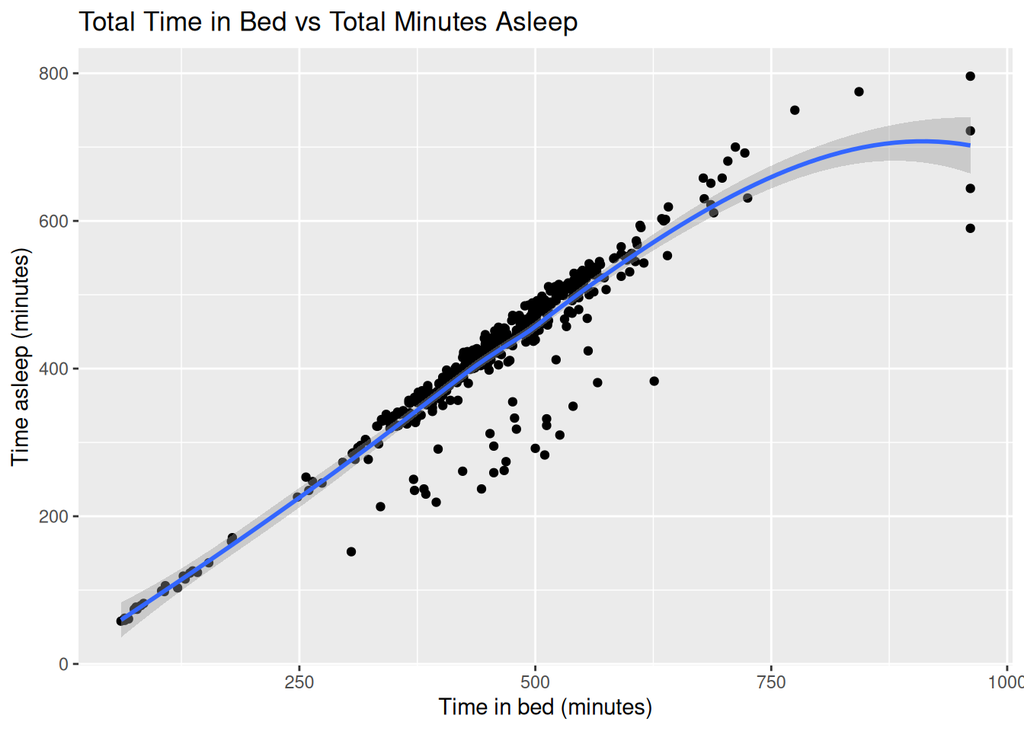

```r
sleep %>%
  ggplot(mapping = aes(x = total_time_in_bed, y = total_minutes_asleep)) + geom_point(stat = 'identity') + geom_smooth() +
  labs(title = "Total Time in Bed vs Total Minutes Asleep", x = "Time in bed (minutes)", y = "Time asleep (minutes)")
```

*Observation:* We observe that the more time one stays on bed the more likelihood it is for him to be asleep. This a positive correlation.

*Hourly Intensity* First we create a table to hold the data that we will use for this visualization;

```r
# Hourly average intensity
hourly_int <- intensities %>%
  group_by(time) %>%
  drop_na() %>%
  summarise(avg_inte = mean(total_intensity))
```

Then we visualize the data using a histogram to view the hourly intensity as it compares through each hour of the day and know the time when the customers are most active.

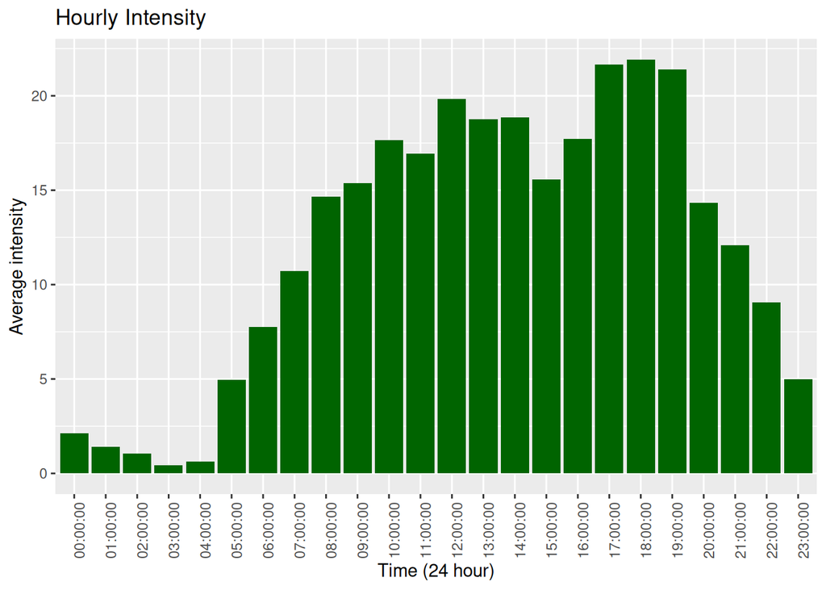

```r
hourly_int %>%
  ggplot(mapping = aes(x=time, y = avg_inte)) + geom_histogram(stat = "identity", fill = "darkgreen") +
  theme(axis.text.x = element_text(angle = 90)) +
  labs(title = "Hourly Intensity", x="Time (24 hour)", y="Average intensity")
```

## Target Audience

The target audience for the high-tech products from Bellabeat is Women who are working. The products are use to track activities, sleep, stress, mindfulness ensuring the health well-being of these women. The women are always those working in offices and they sit for long hours and time. It is good for them to keep track of their activities both at work and out of work to be able to manage time efficiently in doing other physical activities including walking and even at the gym. They will be able to track the intensity and time for each activity.

## Products

Bellabeats products are the Bellabeat app which is connected with every product Bellabeat and is used to receive data collected from the other wearbles. We have the Leaf which is an innovative product that can either be a necklace, bracelet, or clip. It is fixed with a tracker which is used for tracking user activity, sleep, and stress. We have smart watch used to track all these mentioned activities and relay the data to the APP. Spring which is a water bottle that is used to track daily water intake to ensure that the user is well hydrated.

## Conclusion and Recommendations

#### Conclusion

Bellabeat being a high-tech global company has a potential for growth to becoming a big global company.Since, its inception in 2013 it has grown rapidly to get to where it is and it feel the need for expansion a good sign for growth. Therefore, from the insights gained through analysis of the data below are the recommendations:

#### Recommendations

Bellabeat APP is more than receiving data from all the other products. It can be used to achieve more than it was intended to. 1. The app can be used to set reminders to remind users when they become inactive, or when to undertake a certain activity since from the observations above we found out that the average sedentary active time is 991.2 minute which is almost 17 hrs more than two-thirds of a day. 2. Can set notifications which will be part of the reminders more especially after identifying your trends and when you are most active to keep you on toes. Forexample a notification when your most active time approaches. Also the notifications can be used to alert you when something is wrong or your have by-passed an activity. 3. In addition to the produscts Bellabeat should consider having their watches be used to track down the heart rate. This is very important in keeping an eye on the heartrate of the user.

## Referrence

1. Healy, G. N., Clark, B. K., Winkler, E. A., Gardiner, P. A., Brown, W. J., & Matthews, C. E. (2011). Measurement of adults’ sedentary time in population-based studies. American journal of preventive medicine, 41(2), 216-227.